[output not shown]

```python
# setting up IPython Notebook so that it displays nicely
# you can safely skip this cell...
%pylab inline
pylab.rcParams['figure.figsize'] = (10.0, 5.0)
from pyannote.core.notebook import set_notebook_crop, Segment
set_notebook_crop(Segment(0, 60))
```

# Aligning transcripts with subtitles

Start by loading **The Big Bang Theory** subset of the **TVD dataset**

```python
from tvd import TheBigBangTheory
dataset = TheBigBangTheory('/Volumes/data/tvd/')
```

[output not shown]

For illustration purposes, we will only focus on the first episode of the TV series

```python
firstEpisode = dataset.episodes[0]
print firstEpisode
```

```
TheBigBangTheory.Season01.Episode01
```

By chance, for this episode, both the english transcript and the subtitles are available in the dataset.

```python
transcript = dataset.get_resource('transcript', firstEpisode)
```

**pyannote.parser** provides a subtitle file (.srt) parser.  
It also takes care of dividing (**split=True**) subtitles that cover multiple dialogue lines from several speaker.  
Additionally (**duration=True**), it allottes to each line a duration proportional to their number of words.

```python
from pyannote.parser.srt import SRTParser
parser = SRTParser(split=True, duration=True)
pathToSRTFile = dataset.path_to_subtitles(firstEpisode, language='en')
subtitles = parser.read(pathToSRTFile)
```

For illustration purposes, let us focus on the first minute of the episode.

```python
subtitles = subtitles.crop(0, 60)
transcript = transcript.crop('C', 'T')
```

The **transcript** provides the exact transcription of the dialogues and characters' names.  
However, it does not contain any timing information (other than the obvious chronological order).

```python
transcript
```

[figure not shown]

On the other hand, **subtitles** only provide coarse dialogue transcription.  
However, they do provide raw timing information.

```python
subtitles
```

[figure not shown]

Our objective here is to combine those two sources of information in order to get as close as possible to the actual reference annotation:

[figure not shown]

```python
reference = dataset.get_resource('speaker', firstEpisode)
# 'speaker' resources contains plenty of labels (e.g music, applause, silence, etc...)
# we are only going to use the ones starting by 'speech_'
# (e.g. speech_sheldon, speech_penny, speech_raj, etc...)
reference = reference.subset(set([label for label in reference.labels() if label.startswith('speech')]))
# next, for better display below, we change each 'speech_somebody' label in 'SOMEBODY'
# (e.g speech_sheldon becomes SHELDON)
reference = reference.translate({label: label[7:].upper() for label in reference.labels()})
# now, we just keep the first minute for illustration purposes
reference = reference.crop(Segment(0,60))
# this should display nicely in IPython Notebook
reference
```

We are now going to use dynamic time warping to align the **transcript** with the **subtitles** based on the actual text.

```python
from pyannote.features.text.preprocessing import TextPreProcessing
from pyannote.features.text.tfidf import TFIDF

# this is the default text (i.e. subtitles or speech transcript) pre-processing
preprocessing = TextPreProcessing(
    tokenize=True,    # step 1: tokenization of sentences into words
    lemmatize=True,   # step 2: lemmatization
    stem=True,        # step 3: stemming
    stopwords=True,   # step 4: remove stop-words
    pos_tag=True,
    keep_pos=True,    # step 5: only keep nouns, adjectives, verbs and adverbs
    min_length=2)     # step 6: remove stems shorter than 2 letters

# this is the TF-IDF transformer that will project
# each pre-processed text into a fixed-size vector
tfidf = TFIDF(preprocessing=preprocessing,  # use just-defined pre-processing
              binary=True)                  # use binary term-frequency
```

The actual alignment is done by an instance of **TFIDFAlignment** (more details on what it does below).

```python
from pyannote.algorithms.alignment.transcription import TFIDFAlignment
aligner = TFIDFAlignment(tfidf, adapt=True)
merged = aligner(transcript, subtitles, vattribute='speech', hattribute='subtitle')
```

Bam! Merged!

```python
merged
```

[figure not shown]

We end up with a timestamped transcript which could, in turn, be used to train acoustic speaker identification models.  
Let us quickly convert it into an **Annotation** object that can be easily visualize:

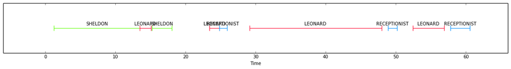

```python
from pyannote.core import Annotation
hypothesis = Annotation()
for start_time, end_time, data in merged.edges_iter(data=True):
    if 'speaker' in data:
        hypothesis[Segment(start_time, end_time)] = data['speaker']
hypothesis
```

See? We managed to obtain a **speaker** annotation not that far away from the actual groundtruth:

[figure not shown]

```python
reference
```

### Under the hood (TF-IDF + cosine distance + dynamic time warping)

```python
from pyannote.algorithms.alignment.dtw import DynamicTimeWarping
```

#### TF-IDF

Under the hood, each dialogue line is first changed into a TF-IDF vector

```python
text = 'If a photon is directed through a plane with two slits in it...'
preprocessing(text)
```

```
['photon', 'direct', 'plane', 'slit']
```

```python
vector = tfidf.transform([text])[0,:].toarray().squeeze()
print vector
```

```
[ 0.          0.          0.          0.          0.          0.52200489
  0.          0.          0.          0.          0.          0.          0.
  0.          0.          0.          0.          0.          0.          0.
  0.          0.          0.          0.          0.          0.          0.
  0.          0.52200489  0.          0.47698103  0.          0.          0.
  0.          0.          0.          0.47698103  0.          0.          0.
  0.          0.          0.        ]
```

**vector** has non-zero value only for dimensions corresponding to its words.

```python
for i, value in enumerate(vector):
    if value > 0:   # only print non-zero values
        print tfidf._cv.get_feature_names()[i], value
```

```
direct 0.522004885041
photon 0.522004885041
plane 0.476981026869
slit 0.476981026869
```

#### Cosine distance

Next, cosine distance between all pairs of transcript and subtitle lines is computed.

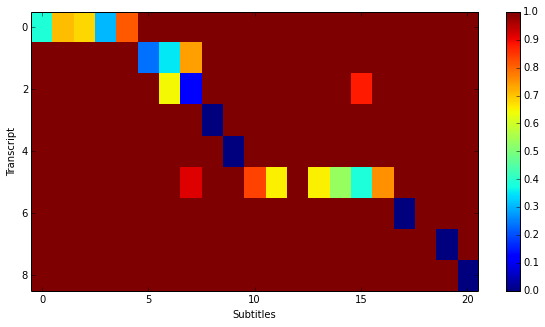

```python
vsequence = aligner._get_sequence(transcript, 'speech')
hsequence = aligner._get_sequence(subtitles, 'subtitle')
distance = aligner.pairwise_distance(vsequence, hsequence)
im = imshow(distance, interpolation='nearest', aspect='auto'); xlabel('Subtitles'); ylabel('Transcript'); colorbar();
```

#### Dynamic time warping

Dynamic time warping ends the process by looking for the path with minimum overall cost (in white below).

```python
dtw = DynamicTimeWarping()
path = dtw(range(len(vsequence)), range(len(hsequence)), distance=distance)
```

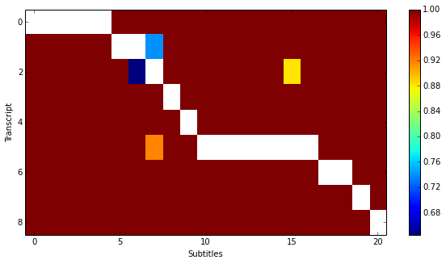

```python
for i, j in path:
    distance[i, j] = np.NaN
imshow(distance, interpolation='nearest', aspect='auto'); xlabel('Subtitles'); ylabel('Transcript'); colorbar();
```